# Linear and Non-Linear Models (31010) Week 1: Homework Assignment

© Yuri Balasanov iLykei.com

**This project helps understanding the linear model as a particular case of generalized linear model**  
**This project is individual**

# 1 Assignment description and preparation for test

In preparation for the test below calculate different outputs of `glm()` using `lm()`.

## 1.1 Reading data

Use the data from file **Week1_Homework_Project_Data.csv** to estimate linear model with `lm()`.  
Analize `summary()` of the estimated linear model.

```r
Linear.Model.Data<-read.csv(file=paste(dataPath,"Week1_Homework_Project_Data.csv",sep="/"),header=TRUE,sep=",")
head(Linear.Model.Data,10)
```

```
##       Output   Input1   Input2       Input3
## 1   5.451630 1.875976 2.721764 -0.011754874
## 2   4.544792 1.713108 2.570596  0.007136568
## 3   5.345051 2.804193 4.700366  0.056975906
## 4  11.239833 3.895376 6.863106 -0.103290465
## 5  10.055252 3.694171 6.405116 -0.142105913
## 6   1.720138 1.104742 1.203397  0.241145841
## 7   9.010973 2.947958 4.968758 -0.059639593
## 8   5.860532 2.743866 4.545334  0.048181014
## 9  13.368089 4.595102 8.226541 -0.189332876
## 10 10.193232 3.639261 6.228819 -0.074765940
```

**What can you tell about the data and the fit?**

## 1.2 Reproducing outputs of `glm()` using `lm()`

By using any outputs of `lm()` or `summary(lm.fit)` calculate the following outputs of `glm()`.

**You can use `glm()` to check your answers, but, please, do not use `glm` object or any functions applied to `glm` object to calculate your results.**

Calculate variables:

1. `coefficients` (5%)
2. `residuals` (5%)
3. `fitted.values` (5%)
4. `linear.predictors` (10%)
5. `deviance` (25%)
   1. Use `deviance()` (10%)
   2. Calculate deviance manually based on the definition given in the lecture (15%)
6. Akaike Information Criterion `aic` (25%)
   1. Obtain it by using `AIC()` (10%)
   2. Calculate it manually using the definition given in the lecture. (15%)
7. `y` (5%)
8. `null.deviance` (10%)
9. `dispersion` (10%)

**As an example, here is solution for the second question.**

2. Residuals.

In the case when data satisfy assumptions of linear moder and identity is selected as link, residuals returned by `glm()` and `lm()` are the same.

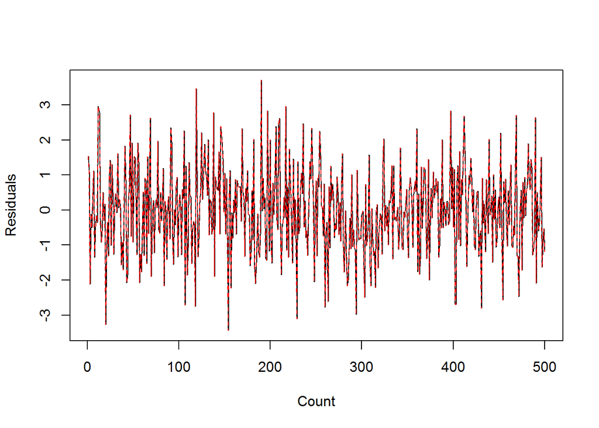

```r
matplot(1:length(Linear.Model.Data[,1]),cbind(Linear.Model.Data.lm$residuals,Linear.Model.Data.glm$residuals),type="l",ylab="Residuals",xlab="Count")
```

```r
sum(abs(Linear.Model.Data.lm$residuals-Linear.Model.Data.glm$residuals)>.00000000001)
```

```
## [1] 0
```

To answer the question create vector of residuals

```r
res<-Linear.Model.Data.lm$residuals
```

Continue answering the questions of this section.

# 2 Test

Answer the same questions using your own sample.

**Be careful using given 5 attempts to submit the test**. When a reset of 5 submissions is requested in order to receive additional 5 attempts, all previous scores are erased. In addition all new scores will be multiplied by 0.95, i.e. maximum score after reset is 95.

[interactive chart not shown]